# SOLUTIONS: Multiple linear regression and diagnostics

Depression among adolescents in Jimma, Ethiopia

GRAPH Courses team

2026-07-16

# Introduction

These are the completed solutions for the Week 9 exercise. Each blank exercise chunk is shown first and not run, followed by a filled solution chunk that runs. The full questions and answers are included.

The data for this exercise come from a study by Girma et al. (2021) titled *Depression and its determinants among adolescents in Jimma town, Southwest Ethiopia*. You can find the published paper in `paper/depression_paper.pdf` and the analysis dataset in `data/depression_data.xls`.

In Week 7, you worked with this same depression dataset using **simple linear regression**, fitting separate models with a single predictor at a time. This week we extend that approach by fitting a **multiple linear regression** model.

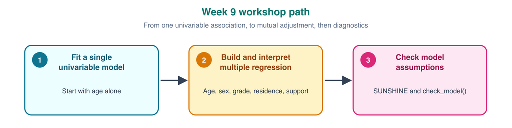

Our outcome variable is the **PHQ-9 depression score**, which is calculated as the sum of responses across nine items and ranges from 0 to 27, with higher values indicating greater severity of depressive symptoms.

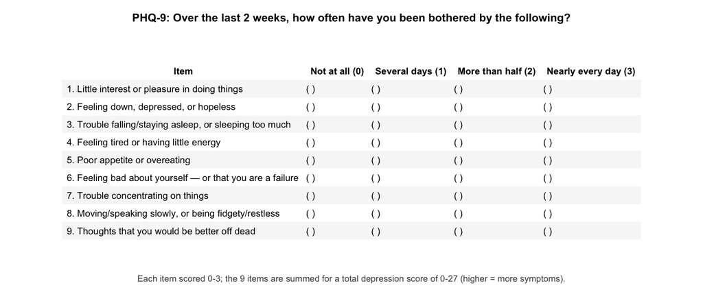

The nine PHQ-9 items and response scale.

# PART 1: What is our regression purpose?

Multiple linear regression can serve different scientific goals.

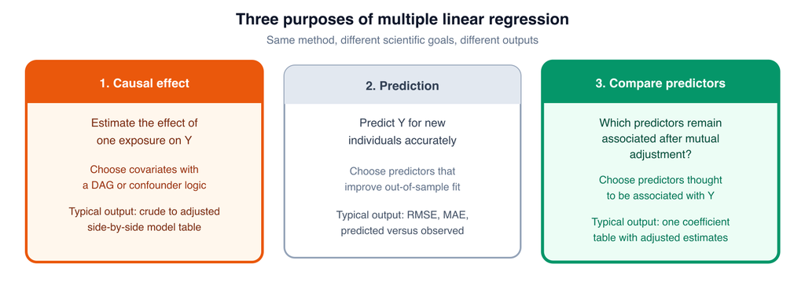

**Question 1.1:** In Week 8 we tried to estimate the effect of smoking on FEV, controlling for other confounders. Which of the three purposes above does that correspond to?

**Ans 1.1:** Purpose 1, estimating a causal or adjusted exposure effect.

**Question 1.2:** This week we will replicate a paper that looked at many different predictors of depression. Which of the three purposes above is that? What kind of table or plot should we probably use for the results?

**Ans 1.2:** Purpose 3, comparing predictors after mutual adjustment. A coefficient table with adjusted estimates is the main output. A forest plot can also help compare coefficients visually.

# PART 2: Load and prepare the data

## Load packages

Use `p_load()` to load: readxl, tidyverse, here, janitor, broom, gt, gtsummary, performance, see, sandwich, lmtest, patchwork. The GitHub line below loads `inspectdf`.

*Exercise chunk (blank):*

```r
if (!require(pacman)) install.packages("pacman")
pacman::p_load(________)
pacman::p_load_gh("the-graph-courses/inspectdf")
```

**Solution:**

```r
if (!require(pacman)) install.packages("pacman")
pacman::p_load(readxl, tidyverse, here, janitor, broom, gt, gtsummary, performance, see, sandwich, lmtest, patchwork)
pacman::p_load_gh("the-graph-courses/inspectdf")
```

## Import and clean the dataset

Import the Excel file, then clean and keep only the variables we need.

```r
survey_raw <- read_excel(here("data/depression_data.xls"))
```

*Exercise chunk (blank):*

```r
# 1. Standardize column names with clean_names().
# 2. Rename columns to clearer names.
# 3. Keep only: depression_score, chronological_age, sex, grade_level, residence, oslo_social_support.

survey <- survey_raw %>%
  ______() %>%
  ______(
    depression_score = scoredep,
    chronological_age = agechron,
    oslo_social_support = osl3,
    sex = sexrespo,
    residence = residece,
    grade_level = gradelev
  ) %>%
  ______(
    depression_score,
    chronological_age,
    sex,
    grade_level,
    residence,
    oslo_social_support
  )

glimpse(survey)
```

**Solution:**

```r
# 1. Standardize column names with clean_names().
# 2. Rename columns to clearer names.
# 3. Keep only: depression_score, chronological_age, sex, grade_level, residence, oslo_social_support.

survey <- survey_raw %>%
  clean_names() %>%
  rename(
    depression_score = scoredep,
    chronological_age = agechron,
    oslo_social_support = osl3,
    sex = sexrespo,
    residence = residece,
    grade_level = gradelev
  ) %>%
  select(
    depression_score,
    chronological_age,
    sex,
    grade_level,
    residence,
    oslo_social_support
  )

glimpse(survey)
```

```
## Rows: 546
## Columns: 6
## $ depression_score    <dbl> 0, 4, 3, 12, 5, 13, 8, 8, 5, 3, 2, 15, 0, 7, 4, 14…
## $ chronological_age   <dbl> 15, 16, 16, 15, 15, 18, 16, 16, 16, 16, 16, 15, 17…
## $ sex                 <dbl> 0, 1, 0, 1, 0, 0, 0, 0, 0, 0, 0, 1, 1, 1, 1, 0, 0,…
## $ grade_level         <dbl> 1, 1, 1, 1, 1, 2, 1, 1, 1, 1, 1, 1, 1, 1, 1, 1, 1,…
## $ residence           <dbl> 0, 0, 0, 0, 0, 0, 0, 0, 0, 0, 0, 0, 0, 0, 0, 0, 0,…
## $ oslo_social_support <dbl> 10, 9, 7, 4, 10, 5, 11, 11, 14, 10, 12, 6, 8, 11, …
```

Take a quick look at the data with `inspect_cat()` and `inspect_num()`.

[figure not shown]

```r
inspect_cat(survey) %>% show_plot()
```

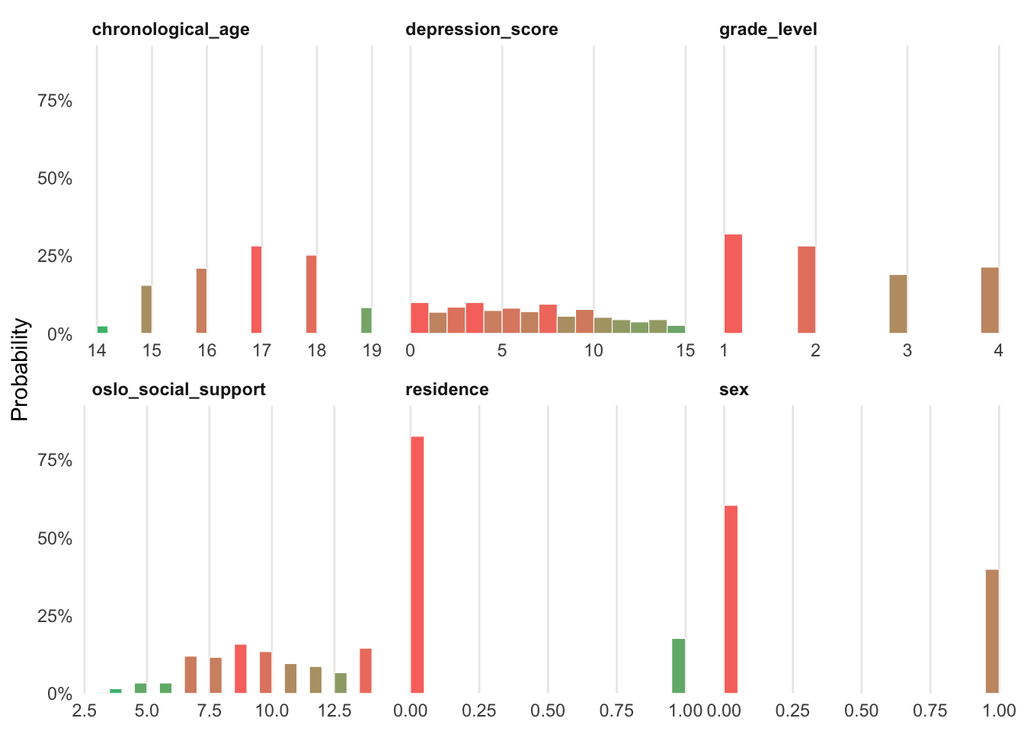

```r
inspect_num(survey) %>% show_plot()
```

**Question 2.1:** Which variables are truly numeric?

**Ans 2.1:** Only `depression_score`, `chronological_age`, and `oslo_social_support` are truly numeric, in the sense that the numbers represent quantities we can meaningfully add or average. (One might also argue that `depression_score` and `oslo_social_support` are not truly numeric, since they are aggregate scores from ordinal categorical variables. So there is wiggle room in interpretation.) `sex`, `grade_level`, and `residence` are stored as numbers, so R treats them as numeric, but the codes are just labels for categories. We fix that below.

Three predictors are categorical but stored as numeric codes. Below, we will label them:

- `sex` (0 = Female, 1 = Male)
- `residence` (0 = Urban, 1 = Rural)
- `grade_level` (1 = Grade 9, 2 = Grade 10, 3 = Grade 11, 4 = Grade 12)

We show `sex` as an example. Fill in the blanks for the other two categorical variables.

*Exercise chunk (blank):*

```r
survey <- survey %>%
  mutate(
    sex = factor(
      sex,
      levels = c(0, 1),
      labels = c("Female", "Male")
    ),
    grade_level = factor(
      grade_level,
      levels = c(1, 2, 3, 4),
      labels = ______
    ),
    residence = factor(
      residence,
      levels = c(0, 1),
      labels = ______
    )
  )
```

**Solution:**

```r
survey <- survey %>%
  mutate(
    sex = factor(
      sex,
      levels = c(0, 1),
      labels = c("Female", "Male")
    ),
    grade_level = factor(
      grade_level,
      levels = c(1, 2, 3, 4),
      labels = c("Grade 9", "Grade 10", "Grade 11", "Grade 12")
    ),
    residence = factor(
      residence,
      levels = c(0, 1),
      labels = c("Urban", "Rural")
    )
  )
```

Check the labeled data again.

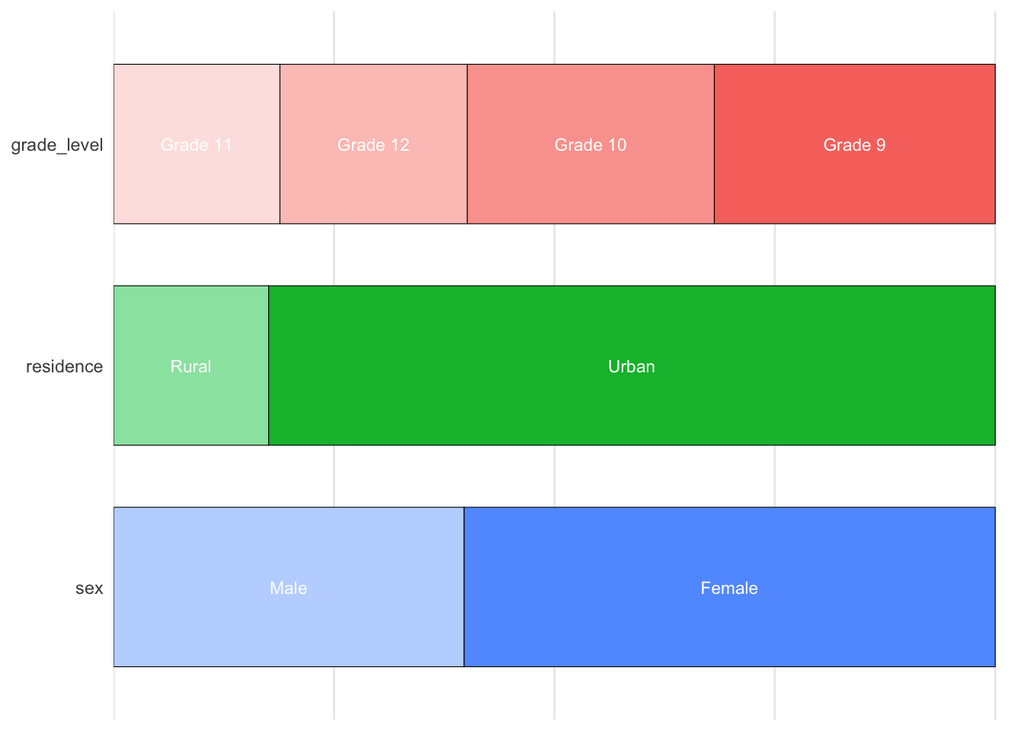

```r
inspect_cat(survey) %>% show_plot()
```

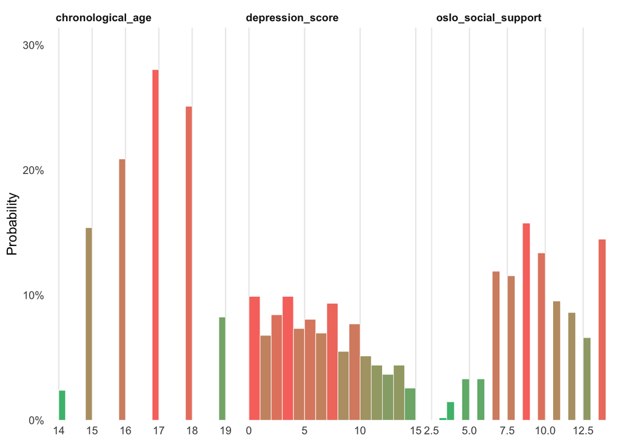

```r
inspect_num(survey) %>% show_plot()
```

# PART 3: Start with simple models

In the depression paper, the authors fits both simple and multiple models and presented the results side by side. This is a common practice in regression analyses for comparing predictors. We’ll do the same here.

Below, complete the code to fit one simple model: `depression_score` as the outcome and `chronological_age` as the only predictor.

*Exercise chunk (blank):*

```r
age_simple <- lm(________ ~ ________, data = survey)
tidy(age_simple, conf.int = TRUE)
```

**Solution:**

```r
age_simple <- lm(depression_score ~ chronological_age, data = survey)
tidy(age_simple, conf.int = TRUE)
```

```
## # A tibble: 2 × 7
##   term              estimate std.error statistic p.value conf.low conf.high
##   <chr>                <dbl>     <dbl>     <dbl>   <dbl>    <dbl>     <dbl>
## 1 (Intercept)         -0.760     2.29     -0.332 0.740     -5.26      3.74
## 2 chronological_age    0.447     0.136     3.30  0.00104    0.181     0.714
```

**Question 3.1:** Interpret the age coefficient from the simple model. Does its 95% CI include 0?

**Ans 3.1:** In the simple model, each 1-year increase in chronological age is associated with about **0.45 points higher** PHQ-9 score on average. The 95% CI is about **0.18 to 0.71**, so it excludes 0.

Let’s now fit the remaining simple models. We will combine these with the multiple model in the next part.

```r
sex_simple <- lm(depression_score ~ sex, data = survey)
grade_simple <- lm(depression_score ~ grade_level, data = survey)
residence_simple <- lm(depression_score ~ residence, data = survey)
support_simple <- lm(depression_score ~ oslo_social_support, data = survey)
```

# PART 4: Build and interpret a multiple regression

Now, complete the code to fit one multiple linear regression model with all five predictors.

*Exercise chunk (blank):*

```r
# Outcome: depression_score
# Predictors: chronological_age, sex, grade_level, residence, oslo_social_support

multivar_model <- lm(
  ________________ ~ ________________,
  data = survey
)

# summary of your model
summary(________)
```

**Solution:**

```r
# Outcome: depression_score
# Predictors: chronological_age, sex, grade_level, residence, oslo_social_support

multivar_model <- lm(
  depression_score ~ chronological_age + sex + grade_level + residence + oslo_social_support,
  data = survey
)

# summary of your model
summary(multivar_model)
```

```
##
## Call:
## lm(formula = depression_score ~ chronological_age + sex + grade_level +
##     residence + oslo_social_support, data = survey)
##
## Residuals:
##     Min      1Q  Median      3Q     Max
## -8.8950 -2.8506  0.2506  2.5500  9.3902
##
## Coefficients:
##                     Estimate Std. Error t value Pr(>|t|)
## (Intercept)          9.61378    3.20715   2.998  0.00285 **
## chronological_age    0.15188    0.20169   0.753  0.45177
## sexMale             -1.03962    0.31998  -3.249  0.00123 **
## grade_levelGrade 10  0.84854    0.48994   1.732  0.08386 .
## grade_levelGrade 11  0.87067    0.59488   1.464  0.14389
## grade_levelGrade 12  1.49658    0.68758   2.177  0.02995 *
## residenceRural       1.29341    0.41310   3.131  0.00184 **
## oslo_social_support -0.59938    0.05877 -10.198  < 2e-16 ***
## ---
## Signif. codes:  0 '***' 0.001 '**' 0.01 '*' 0.05 '.' 0.1 ' ' 1
##
## Residual standard error: 3.599 on 538 degrees of freedom
## Multiple R-squared:  0.2139, Adjusted R-squared:  0.2036
## F-statistic: 20.91 on 7 and 538 DF,  p-value: < 2.2e-16
```

Now, print the same model in tidy form with confidence intervals.

```r
tidy(multivar_model, conf.int = TRUE)
```

```
## # A tibble: 8 × 7
##   term                estimate std.error statistic  p.value conf.low conf.high
##   <chr>                  <dbl>     <dbl>     <dbl>    <dbl>    <dbl>     <dbl>
## 1 (Intercept)            9.61     3.21       3.00  2.85e- 3    3.31     15.9
## 2 chronological_age      0.152    0.202      0.753 4.52e- 1   -0.244     0.548
## 3 sexMale               -1.04     0.320     -3.25  1.23e- 3   -1.67     -0.411
## 4 grade_levelGrade 10    0.849    0.490      1.73  8.39e- 2   -0.114     1.81
## 5 grade_levelGrade 11    0.871    0.595      1.46  1.44e- 1   -0.298     2.04
## 6 grade_levelGrade 12    1.50     0.688      2.18  2.99e- 2    0.146     2.85
## 7 residenceRural         1.29     0.413      3.13  1.84e- 3    0.482     2.10
## 8 oslo_social_support   -0.599    0.0588   -10.2   1.90e-22   -0.715    -0.484
```

In a multiple model, each coefficient is a **conditional association**. It compares observations that differ on one predictor but are held constant on the other predictors in the model.

**Question 4.1:** Interpret `sexMale` in the multiple model output. Use the phrase “holding the other predictors constant” in your answer.

**Ans 4.1:** Males score about **1.04 points lower** on the PHQ-9 than females on average, holding the other predictors constant (chronological age, grade level, residence, and Oslo social support).

## Compare the age coefficient in the simple and multiple models

Let’s compare the age coefficient in the simple and multiple models.

```r
tidy(age_simple, conf.int = TRUE) %>%
  filter(term == "chronological_age")
```

```
## # A tibble: 1 × 7
##   term              estimate std.error statistic p.value conf.low conf.high
##   <chr>                <dbl>     <dbl>     <dbl>   <dbl>    <dbl>     <dbl>
## 1 chronological_age    0.447     0.136      3.30 0.00104    0.181     0.714
```

```r
tidy(multivar_model, conf.int = TRUE) %>%
  filter(term == "chronological_age")
```

```
## # A tibble: 1 × 7
##   term              estimate std.error statistic p.value conf.low conf.high
##   <chr>                <dbl>     <dbl>     <dbl>   <dbl>    <dbl>     <dbl>
## 1 chronological_age    0.152     0.202     0.753   0.452   -0.244     0.548
```

**Question 4.2:** In the simple model, the age coefficient was 0.447 and looked clearly associated with depression score. What changed in the multiple model?

**Ans 4.2:** Two things. The **estimate** shrank by about two thirds, from 0.447 to about **0.15** points per year. And the association is **no longer significant**: the 95% CI moved from 0.18 to 0.71 (excluding 0) to about **-0.24 to 0.55** (including 0). So once the other predictors are in the model, age no longer has a clear association with depression score.

Look at how age varies within each grade.

```r
survey %>%
  group_by(grade_level) %>%
  summarise(
    mean_age = mean(chronological_age),
    min_age = min(chronological_age),
    max_age = max(chronological_age)
  )
```

```
## # A tibble: 4 × 4
##   grade_level mean_age min_age max_age
##   <fct>          <dbl>   <dbl>   <dbl>
## 1 Grade 9         15.5      14      19
## 2 Grade 10        16.9      15      19
## 3 Grade 11        17.4      16      19
## 4 Grade 12        18.2      17      19
```

**Question 4.3:** Fill in the blanks. Choose from the options in parentheses.

In the simple model, age compares students across all grades. In the multiple model, the age coefficient compares older versus younger students ______ (across all grades / within the same grade), because grade is already in the model. Within each grade, age does not vary much, which is one reason the age association ______ (strengthens / weakens) after adjustment.

**Filled in:** within the same grade; weakens

In addition, grade level is also largely a consequence of age. In causal terms, grade is more like a **mediator** of age’s association with depression than a confounder. By controlling for grade, we remove part of the total effect that age would otherwise carry.

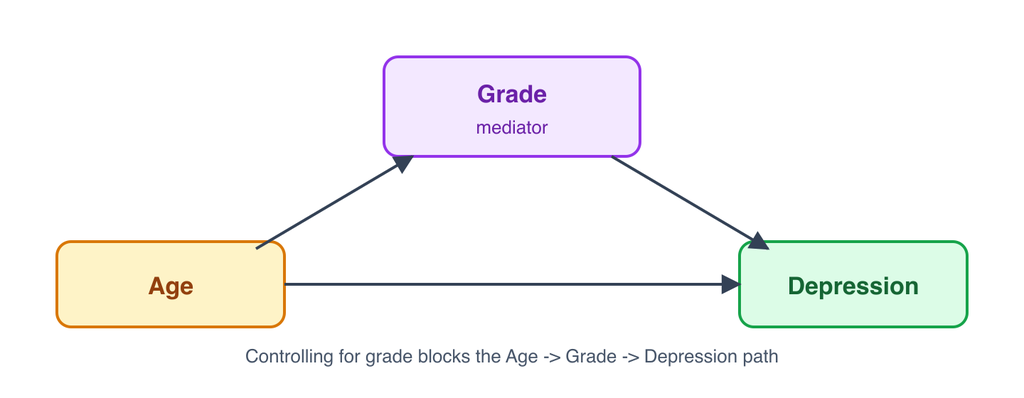

This overlap is another reason to avoid causal language here. We are comparing adjusted associations, not estimating total causal effects. If we were interested in the causal effect of age on depression, we would generally *avoid* adjusting for such mediators.

# PART 5: Build a results table like the paper

Table 2 in the paper shows both simple and adjusted results side by side. That is what we are trying to reproduce (Caveat: We are only replicating a few of the predictors).

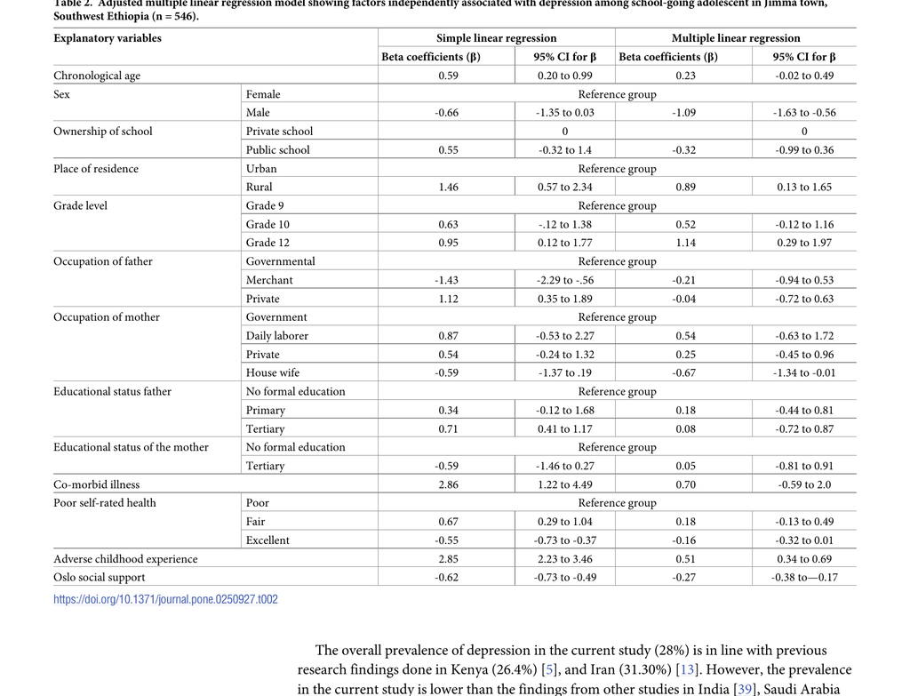

Table 2 from Girma et al. (2021).

## A quick table with `gtsummary`

The `gtsummary` package can turn a fitted model into a readable table automatically.

```r
multivar_model %>%
  tbl_regression()
```

| **Characteristic** | **Beta** | **95% CI** | **p-value** |
| --- | --- | --- | --- |
| chronological_age | 0.15 | -0.24, 0.55 | 0.5 |
| sex |  |  |  |
| Female | — | — |  |
| Male | -1.0 | -1.7, -0.41 | 0.001 |
| grade_level |  |  |  |
| Grade 9 | — | — |  |
| Grade 10 | 0.85 | -0.11, 1.8 | 0.084 |
| Grade 11 | 0.87 | -0.30, 2.0 | 0.14 |
| Grade 12 | 1.5 | 0.15, 2.8 | 0.030 |
| residence |  |  |  |
| Urban | — | — |  |
| Rural | 1.3 | 0.48, 2.1 | 0.002 |
| oslo_social_support | -0.60 | -0.71, -0.48 | <0.001 |

Abbreviation: CI = Confidence Interval

This is useful, but it only summarizes one model at a time. It does not let us place simple and adjusted results side by side in one paper-style table.

For that, we need some custom formatting code. We have prepared this code for you, and as you can see, it is quite intricate. As we have recommended before, for this kind of table-building code, it is probably expedient to lean on LLMs, *as long as you verify that the output tables you receive match the raw outputs from the code you actually understand (your `lm()`, `summary()` and `tidy()` calls).*

```r
cont_rows <- function(model, var_name, var_label, level_label) {
  tidy(model, conf.int = TRUE) %>%
    filter(term == var_name) %>%
    transmute(
      variable = var_label,
      level = level_label,
      beta = estimate,
      low = conf.low,
      high = conf.high
    )
}

cat_rows <- function(model, var_name, var_label, ref_label) {
  non_ref <- tidy(model, conf.int = TRUE) %>%
    filter(term != "(Intercept)", str_starts(term, var_name)) %>%
    mutate(level = str_remove(term, var_name)) %>%
    transmute(
      variable = var_label,
      level,
      beta = estimate,
      low = conf.low,
      high = conf.high
    )

  ref <- tibble(
    variable = var_label,
    level = ref_label,
    beta = 0,
    low = NA_real_,
    high = NA_real_
  )

  bind_rows(ref, non_ref)
}

format_beta_ci <- function(beta, low, high) {
  if_else(
    is.na(low),
    "Reference",
    paste0(
      format(round(beta, 2), nsmall = 2), " (",
      format(round(low, 2), nsmall = 2), " to ",
      format(round(high, 2), nsmall = 2), ")"
    )
  )
}
```

Build simple and adjusted rows, then combine them into one table.

```r
simple_results <- bind_rows(
  cont_rows(age_simple, "chronological_age", "Chronological age", "Per 1-year increase"),
  cat_rows(sex_simple, "sex", "Sex", ref_label = "Female"),
  cat_rows(grade_simple, "grade_level", "Grade level", ref_label = "Grade 9"),
  cat_rows(residence_simple, "residence", "Place of residence", ref_label = "Urban"),
  cont_rows(support_simple, "oslo_social_support", "Oslo social support", "Per 1-point increase")
) %>%
  mutate(model = "Simple")
```

```r
adjusted_results <- bind_rows(
  cont_rows(multivar_model, "chronological_age", "Chronological age", "Per 1-year increase"),
  cat_rows(multivar_model, "sex", "Sex", ref_label = "Female"),
  cat_rows(multivar_model, "grade_level", "Grade level", ref_label = "Grade 9"),
  cat_rows(multivar_model, "residence", "Place of residence", ref_label = "Urban"),
  cont_rows(multivar_model, "oslo_social_support", "Oslo social support", "Per 1-point increase")
) %>%
  mutate(model = "Multiple")
```

```r
combined_results <- bind_rows(simple_results, adjusted_results) %>%
  mutate(`Beta (95% CI)` = format_beta_ci(beta, low, high)) %>%
  select(variable, level, model, `Beta (95% CI)`)

results_table <- combined_results %>%
  pivot_wider(names_from = model, values_from = `Beta (95% CI)`) %>%
  gt(groupname_col = "variable", rowname_col = "level") %>%
  tab_header(
    title = "Factors associated with PHQ-9 depression score",
    subtitle = "Simple and multiple linear regression"
  ) %>%
  tab_style(style = cell_text(weight = "bold"), locations = cells_row_groups()) %>%
  tab_options(table.width = pct(100))

results_table
```

Factors associated with PHQ-9 depression score

Simple and multiple linear regression

|  | Simple | Multiple |
| --- | --- | --- |
| Chronological age |  |  |
| Per 1-year increase | 0.45 ( 0.18 to 0.71) | 0.15 (-0.24 to 0.55) |
| Sex |  |  |
| Female | Reference | Reference |
| Male | -0.66 (-1.35 to 0.03) | -1.04 (-1.67 to -0.41) |
| Grade level |  |  |
| Grade 9 | Reference | Reference |
| Grade 10 | 1.34 ( 0.47 to 2.21) | 0.85 (-0.11 to 1.81) |
| Grade 11 | 0.88 (-0.10 to 1.85) | 0.87 (-0.30 to 2.04) |
| Grade 12 | 1.64 ( 0.70 to 2.58) | 1.50 ( 0.15 to 2.85) |
| Place of residence |  |  |
| Urban | Reference | Reference |
| Rural | 1.46 ( 0.57 to 2.34) | 1.29 ( 0.48 to 2.10) |
| Oslo social support |  |  |
| Per 1-point increase | -0.62 (-0.73 to -0.50) | -0.60 (-0.71 to -0.48) |

**Question 5.1:** Based on the multiple regression results, which variables/levels are significantly associated with higher depression scores?

**Ans 5.1:** Two: **Grade 12** (versus Grade 9), with an adjusted beta of about 1.50 (95% CI 0.15 to 2.85), and **rural residence** (versus urban), with an adjusted beta of about 1.29 (95% CI 0.48 to 2.10). Both are positive with CIs that exclude 0.

Note the wording of the question: *higher* scores. Two other predictors are also significant, but in the opposite direction, so they are associated with **lower** depression scores: **male sex** (beta about -1.04, 95% CI -1.67 to -0.41) and **Oslo social support** (beta about -0.60 per point, 95% CI -0.71 to -0.48). Chronological age, Grade 10, and Grade 11 have CIs that include 0, so they are not significant.

## Export the table

A `gt` table can be exported with `gtsave()`. The file extension sets the format, so `.docx` gives you a Word document.

```r
dir.create(here("outputs"), showWarnings = FALSE)

results_table %>%
  gtsave(here("outputs/regression_table.docx"))
```

The file is written to the `outputs` folder.

# PART 6: Regression diagnostics

We will now check whether the model assumptions look reasonable. The diagram below shows some of the checks that we will perform. If you want a more detailed refresher on what each diagnostic panel means, see the [Regression Diagnostics Explorer](https://the-graph-courses.github.io/rsr_resources/explorers/regression-diagnostics).

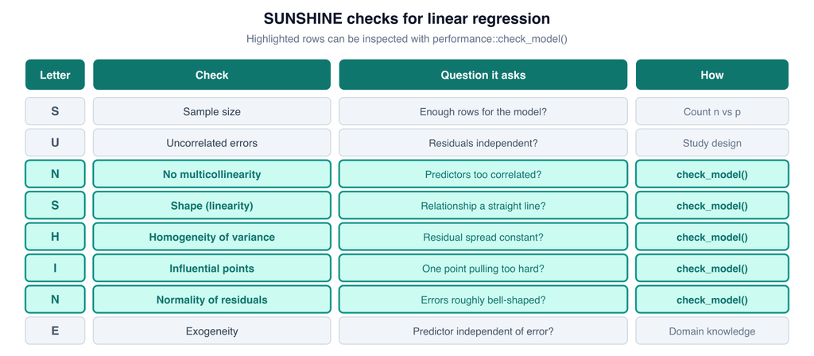

## Sample size and design checks

**Question 6.1:** Our final model has how many parameters? (This is the number of coefficient rows in the model output, including the intercept.)

**Ans 6.1:** The model has **8** parameters: the intercept plus seven predictor terms.

**Question 6.2:** Based on the guideline that we should have at least 10 observations per parameter, do we have enough data to be fitting such a regression model?

**Ans 6.2:** Yes. With **546** observations and **8** parameters, we have about **68** observations per parameter, well above the rough rule of 10.

**Question 6.3:** Students were sampled from a few schools. There may be some correlation of outcomes, and therefore residuals, within schools. Which SUNSHINE letter might be most affected by this?

**Ans 6.3:** It mainly threatens **U**, uncorrelated errors. Students in the same school may have correlated residuals because they share school context. That is a study-design issue, not a normality issue.

The usual fix for this kind of within-cluster correlation is to compute cluster-robust standard errors, using school as the clustering variable. However, the released dataset does not include a school identifier, so we have no way to group students by school and cannot compute those cluster-robust SEs here. This is worth flagging as a limitation when reporting the results: our standard errors may be too small because we could not account for clustering by school.

## Run `check_model()`

Now, let’s run the full diagnostic panel for the checks that can be performed visually.

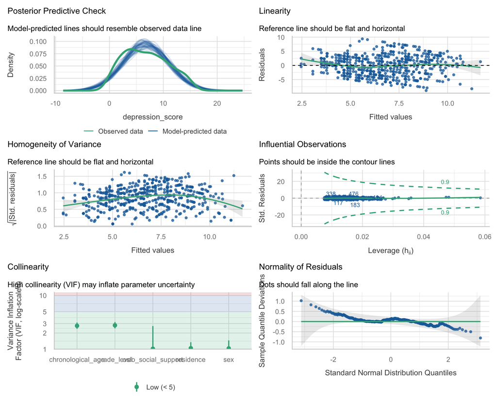

```r
check_model(multivar_model)
```

Use the plots to answer the questions below.

**Question 6.4:** Which predictors show the highest collinearity? Is it severe?

**Ans 6.4:** Chronological age and grade level show the highest collinearity. This matches the age-by-grade table. The VIF values are around 2.7 to 2.8, so the overlap is real but not severe by common teaching thresholds such as 5 or 10.

**Question 6.5:** How would you read the linearity, homogeneity, influential-observations, and normality panels?

**Ans 6.5:**

Homogeneity: The clearest concern because the curve is not flat; this is worth following up.

Influential observations: Look good, with no Cook’s-distance problem.

Normality: Imperfect at the ends, but with n = 546 this is usually less troubling than it would be in a small sample.

## Formal follow-up checks

From the plots above, the two assumptions that look most worrying are **homogeneity of variance** and **normality of residuals**. Let’s check those formally below.

```r
check_heteroscedasticity(multivar_model)
```

[output not shown]

Because heteroscedasticity is flagged, let’s calculate heteroscedasticity-robust standard errors as a sensitivity check. We use HC3 robust SE here. Cluster-robust SE would require a real clustering variable, such as school ID, which is not in this reduced workshop dataset.

```r
coeftest(multivar_model, vcov. = vcovHC(multivar_model, type = "HC3"))
```

```
##
## t test of coefficients:
##
##                      Estimate Std. Error  t value  Pr(>|t|)
## (Intercept)          9.613779   3.163696   3.0388  0.002491 **
## chronological_age    0.151877   0.197149   0.7704  0.441419
## sexMale             -1.039621   0.322850  -3.2201  0.001359 **
## grade_levelGrade 10  0.848543   0.485272   1.7486  0.080932 .
## grade_levelGrade 11  0.870668   0.580298   1.5004  0.134102
## grade_levelGrade 12  1.496584   0.672952   2.2239  0.026569 *
## residenceRural       1.293407   0.409665   3.1572  0.001682 **
## oslo_social_support -0.599381   0.057405 -10.4413 < 2.2e-16 ***
## ---
## Signif. codes:  0 '***' 0.001 '**' 0.01 '*' 0.05 '.' 0.1 ' ' 1
```

**Question 6.6:** Earlier we found that sex, Grade 12, rural residence, and Oslo social support were significantly associated with depression score. Using the robust standard errors, are these same predictors still significant?

**Ans 6.6:** Yes. The HC3 robust results keep the same main conclusions: sex, Grade 12, rural residence, and Oslo social support all remain significant, and chronological age remains non-significant after adjustment. This makes the heteroscedasticity less damaging for the substantive story, though it should still be mentioned.

(If the main conclusions do not change, it is still acceptable to report your original SEs. You may choose to report the assumptions figure and these heteroscedasticity-robust SEs in supplementary material so readers can keep them in mind.)

```r
check_normality(multivar_model)
```

[output not shown]

The check identifies significant deviations from normality. However, in practice, normality of residuals is usually the least important assumption when the sample size is in the hundreds, as it is here. So it is not a major concern.

# Optional challenge: forest plot with LLM help

Some papers combine a coefficient table with a forest plot in one figure. Try to replicate that style for your simple-versus-multiple results, using **ggplot2** and **patchwork**. An LLM can help with the code.

For inspiration, see Fig 2 here: https://gh.bmj.com/content/10/12/e018739#F2

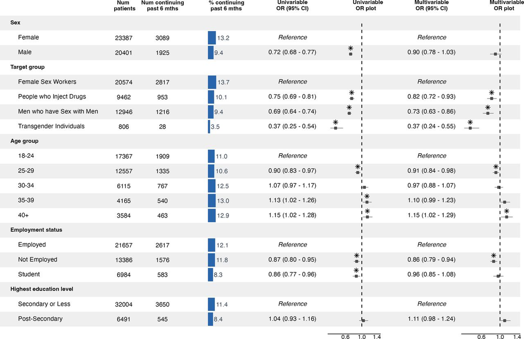

Example figure-table style with coefficient text and forest plots.

You can also look at this script for code you might adapt: https://github.com/kendavidn/yaounde_serocovpop_shared/blob/v1.0.0/scripts/infection_regn_2.R

```r
# Your code here
```